# Project 4: Moral Machine Experiemnt

Tim Hagemeister

06 November, 2019

## Part I: Evaluating the Data Collection Process

**Take a look at the dataset and answer the following questions. Does it look like a complete dataset? Are there any issues with the coding / construction of the dataset? Please report on the following by using R doing some online research.**

1. What is the total number of observations in the dataset? How many observations were you expecting to have in the dataset? What is the size of data we lost in the data collection process?
- The dataset has a total of 807 Observations, this is less than what we expected, this is because there were some rows that did not make sense due to mistakes in the data collection. We expected to have a total of 50 rows for each student in the class, since we have 20 students in the class, we should have had a total of 1,000 data rows of observations. This is about a 20% loss in our data which seems to be quite high.
2. How many accident scenarios have been covered in the actual Moral Machine Experiment? Do you think we – as a class – have made a significant contribution to the data collection?
- There are a total of 40 Million data points that have been collected from over 223 countries. Since we only added less than a thousand, this is not a significant contribution. This is because there are over 223 countries and territories that have participated in the data collection. This means that we have contributed less than 0.025% to the total amount of data
3. How much time did it take you to collect this dataset? Did you use any methods to make the data collection faster and correct?
- It took about 3 hours for the data collection, this is becasue the choices were not always apparent and some of the data that we collected were really difficult with a lot of participants. This made entering the data a lot harder. A trick that i used was to add all of the 0’s in first so that i would only have to enter the variables that actually happened. This made it a lot easier and less teadious to always enter 0’s.
4. Did you notice any problems with the collection of the dataset? Is there any piece of information in the accident scenarios that seem to not have been covered in the data collection?
- There are a lot of points that make this process difficult. Sometimes there are cenarios that are generally the same, this makes making a decision on who to kill and who to save a lot harder. In addition I ended up generally following the law as it was the easiest to track and be fair along the way. This made it hard as normally I would just follow the laws but some instances it was clear to break the law to favor some citizens.
22. Do you trust the data collection done by your classmates? What could be some potential ways of making sure that the data that has been collected is trustable?
- I trust the data that my classmates collected, this is only becasue you wrote a code to get rid of the data that made no sense. This gets rid of a lot of the mistakes that my classmates as well as myself have made. Without this process, I would not trust the data becasue as we see about 20% of the data is not trustable.
6. (If you can remember), please write about 2 or 3 accident scenarios that you have come across in the data collection process that you found to be unrealistic, strange or funny.
- I found a cat and dog driving that decided between killing themselves or killing two dogs, in my opinion, I think that a dogs life is more important so I decided to keep the two dogs alive and kill a dog and a cat. In addition I had a scenario that had two of the same people, I think a woman and a man on one coross walk and another woman and man on the other with nobody in the car. This made it quite weird to decide which one to kill as they were the exact same so i decided to not have the car move the direction as it didnt matter and the car making no choice was better than making a choice to kill a few people.
7. We know that the Moral Machine Experiment is a simplification of the real world. After you have gone through the data collection, what do you think about some potential ways to improve the scenarios and make them more realistic?
- I think that its hard to add variables like the way a person dresses to the factor or age as a computer can not tell how old a person is from a quick appearance. In addition the way a person dresses does not simply imply their profession, for example if I am going to an interview and dressed in a suit, i might seem important, yet if my dad is walking the dogs on a sunday he might be dressed casual, in this case the car might end up saving me because it thinks I am more important whereas my dad in reality is the sucessful one. There are countless of confound variables that come into consideration when making these choices that we do not have the capacity of having a comptuer understand. This is the hard part but I think that we are coming in the right direction. Also the chances of a car having a break fail is very slim, especially right in front of a cross walk in which there is a barrier.

## Part II: Descriptive Statistics and Understanding the Choices

```r
MMD$data_analytics_or_not <- ifelse(grepl("Data Analytics", MMD$intended_or_declared_major_1, MMD$intended_or_declared_major_2,   ignore.case = T), 1,0)

MMD$no_of_siblings <- MMD$no_of_brothers + MMD$no_of_sisters
```

```r
MMD %>%
    tab_cells(age, grown_up_in_US, grown_up_in_a_foreign_country, no_of_brothers, no_of_sisters, data_analytics_or_not, no_of_siblings) %>%
    tab_cols(total(label = "#Total")) %>%
    tab_stat_fun("Mean" = w_mean,
                 "S.D." = w_sd,
                 "min" = w_min,
                 "max" = w_max,
                 "Var." = w_var,
                 "median" = w_median,
                  method = list) %>%
    tab_pivot() %>%
    htmlTable(., css.cell = c("width: 100px",
                              rep("width: 120px", ncol(.) - 1)))
```

|  | #Total Mean | #Total S.D. | #Total min | #Total max | #Total Var. | #Total median |
| --- | --- | --- | --- | --- | --- | --- |
| age | 18.7 | 1.0 | 18 | 21 | 1.0 | 18 |
| grown_up_in_US | 0.6 | 0.5 | 0 | 1 | 0.2 | 1 |
| grown_up_in_a_foreign_country | 0.4 | 0.5 | 0 | 1 | 0.2 | 0 |
| no_of_brothers | 0.8 | 0.6 | 0 | 2 | 0.3 | 1 |
| no_of_sisters | 0.7 | 0.8 | 0 | 2 | 0.6 | 0 |
| data_analytics_or_not | 0.4 | 0.5 | 0 | 1 | 0.2 | 0 |
| no_of_siblings | 1.4 | 0.9 | 0 | 4 | 0.9 | 1 |

### Take a look at the demographic infomration in the dataset. This part will provide us a demographic summary of the class

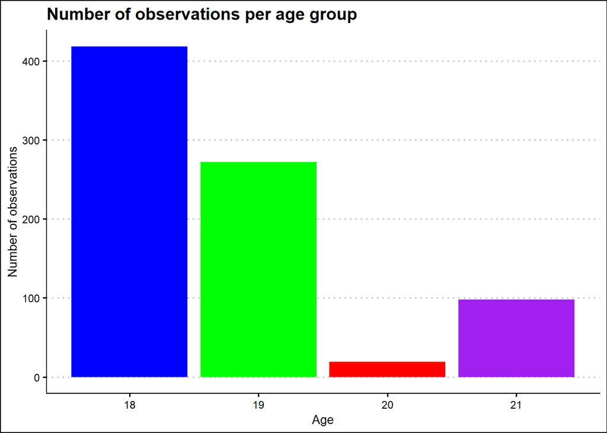

```r
ggplot(MMD, aes(x = age)) +
    geom_bar(fill = c("blue", "green", "red", "purple"))+
    theme_clean()+
     xlab("Age")+
    ylab("Number of observations")+
    ggtitle("Number of observations per age group")
```

```r
data <- data.frame(
  category=c("Female", "Male"),
  count=c(273,534)
)

# Compute percentages
data$fraction <- data$count / sum(data$count)

# Compute the cumulative percentages (top of each rectangle)
data$ymax <- cumsum(data$fraction)

# Compute the bottom of each rectangle
data$ymin <- c(0, head(data$ymax, n=-1))

# Compute label position
data$labelPosition <- (data$ymax + data$ymin) / 2

# Compute a good label
data$label <- paste0(data$category, "\n value: ", data$count)

# Make the plot
second <- ggplot(data, aes(ymax=ymax, ymin=ymin, xmax=4, xmin=3, fill=category)) +
  geom_rect() +
  geom_label( x=3.5, aes(y=labelPosition, label=label), size=3) +
  scale_fill_brewer(palette=4) +
  coord_polar(theta="y") +
  xlim(c(2, 4)) +
  theme_void() +
  ggtitle("Gender Distribution")+
  theme(legend.position = "none")
```

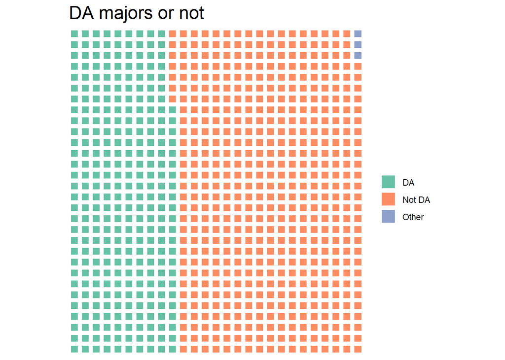

```r
library(waffle)



parts <- c("DA" = 293, "Not DA" = 514, "Other" = 3)
waffle(parts, rows = 30)+
    ggtitle("DA majors or not")
```

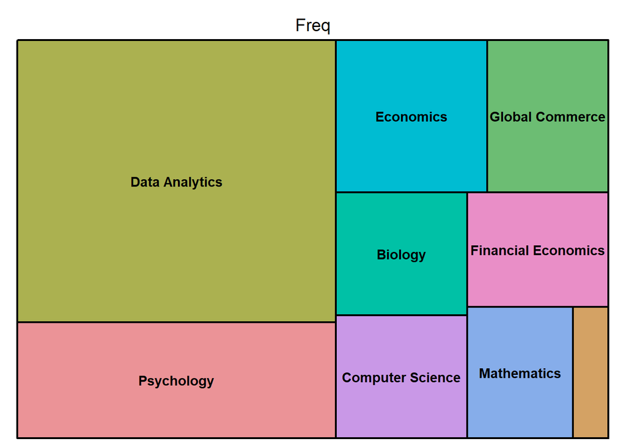

```r
count_table1 <- table(MMD$intended_or_declared_major_1)
ratio_table1 <- round(prop.table(count_table1), digits=2)
DFF1 <- as.data.frame(ratio_table1)

treemap(DFF1, index = c("Var1"), vSize = "Freq")
```

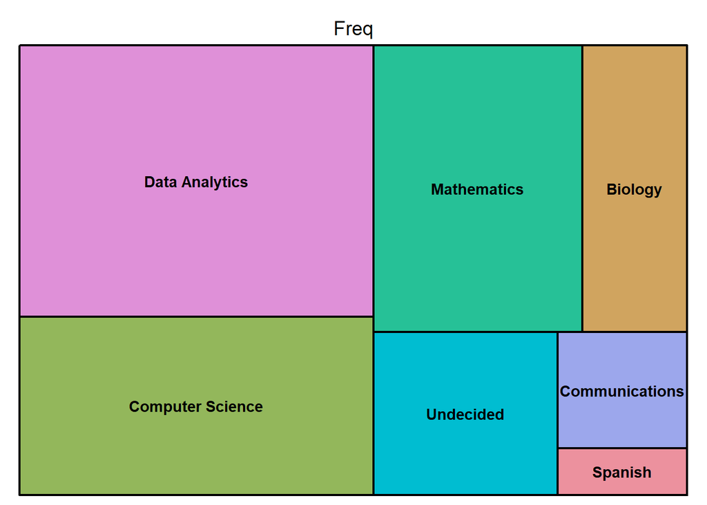

```r
count_table2 <- table(MMD$intended_or_declared_major_2)
ratio_table2 <- round(prop.table(count_table2), digits=2)
DFF2 <- as.data.frame(ratio_table2)

treemap(DFF2, index = c("Var1"), vSize = "Freq")
```

```r
#table(MMD$country_of_origin)


data <- data.frame(
  category=c("China", "Germany", "India", "South Korea", "USA"),
  count=c(144, 48, 50, 50, 515)
)

# Compute percentages
data$fraction <- data$count / sum(data$count)

# Compute the cumulative percentages (top of each rectangle)
data$ymax <- cumsum(data$fraction)

# Compute the bottom of each rectangle
data$ymin <- c(0, head(data$ymax, n=-1))

# Compute label position
data$labelPosition <- (data$ymax + data$ymin) / 2

# Compute a good label
data$label <- paste0(data$category, "\n value: ", data$count)

# Make the plot
six <- ggplot(data, aes(ymax=ymax, ymin=ymin, xmax=4, xmin=3, fill=category)) +
  geom_rect() +
  geom_label( x=3.5, aes(y=labelPosition, label=label), size=3) +
  scale_fill_brewer(palette=4) +
  coord_polar(theta="y") +
  xlim(c(2, 4)) +
  theme_void()+
  ggtitle("Country distribution")+
  theme(legend.position = "none")
```

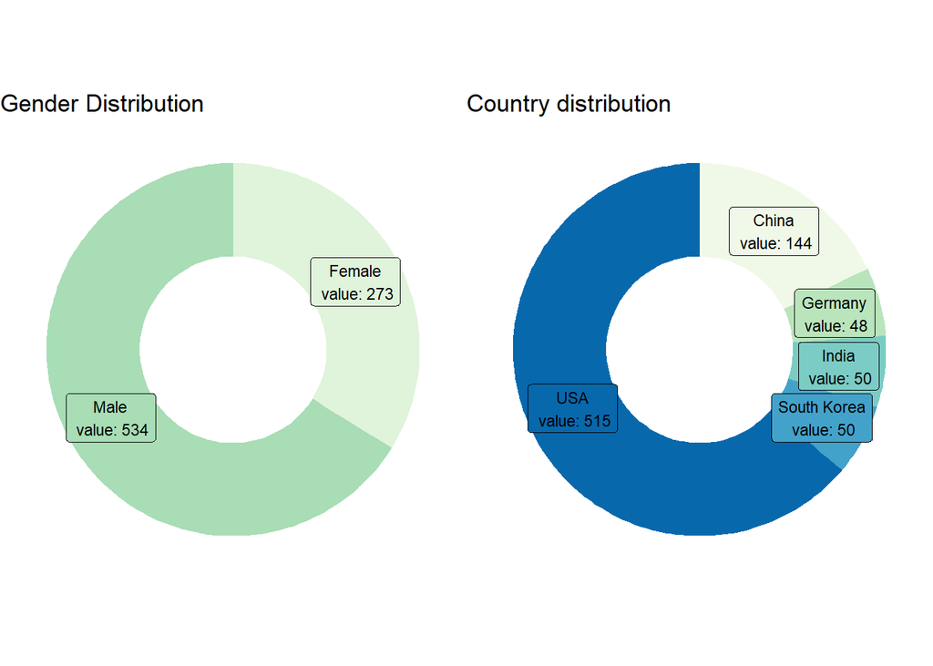

```r
ggarrange(second, six)
```

```r
types_of_actors = c('man', 'woman', "boy", "girl", "elderly_man", "elderly_woman", "large_man", "large_woman", "male_executive", "female_executive", "male_doctor", "female_doctor", "male_athlete", "female_athlete", "pregnant_woman", "homeless_person", "criminal", "baby", "dog", "cat")

types_of_observations <- c('my_actor_no_of_passengers_died', 'my_actor_no_of_pedestrians_on_lane_ahead_died', 'my_actor_no_of_pedestrians_on_other_lane_died', 'my_actor_no_of_passengers_saved', 'my_actor_no_of_pedestrians_on_lane_ahead_saved', 'my_actor_no_of_pedestrians_on_other_lane_saved')

for (actor in types_of_actors){
#Let’s change the names of the columns
updated_types_of_observations <- gsub("my_actor", actor, types_of_observations)
#Let’s find the associated sub-dataset
my_subdataset <- MMD[updated_types_of_observations]
#Let’s find the sums of columns from the dataset
row_Sums = rowSums(my_subdataset, na.rm = TRUE)
#And finally, let’s add the new column to our dataset

MMD[paste("no_of_", actor, sep="")] <- as.vector(row_Sums)
}
```

```r
types_of_actors = c('man', 'woman', "boy", "girl", "elderly_man", "elderly_woman", "large_man", "large_woman", "male_executive", "female_executive", "male_doctor", "female_doctor", "male_athlete", "female_athlete", "pregnant_woman", "homeless_person", "criminal", "baby", "dog", "cat")

types_of_observations <- c('my_actor_no_of_passengers_died', 'my_actor_no_of_pedestrians_on_lane_ahead_died', 'my_actor_no_of_pedestrians_on_other_lane_died')

for (actor in types_of_actors){
#Let’s change the names of the columns
updated_types_of_observations <- gsub("my_actor", actor, types_of_observations)
#Let’s find the associated sub-dataset
my_subdataset <- MMD[updated_types_of_observations]
#Let’s find the sums of columns from the dataset
row_Sums = rowSums(my_subdataset, na.rm = TRUE)
#And finally, let’s add the new column to our dataset

MMD[paste("no_of_", actor, sep="", "_died")] <- as.vector(row_Sums)
}
```

```r
types_of_actors = c('man', 'woman', "boy", "girl", "elderly_man", "elderly_woman", "large_man", "large_woman", "male_executive", "female_executive", "male_doctor", "female_doctor", "male_athlete", "female_athlete", "pregnant_woman", "homeless_person", "criminal", "baby", "dog", "cat")

types_of_observations <- c('my_actor_no_of_passengers_saved', 'my_actor_no_of_pedestrians_on_lane_ahead_saved', 'my_actor_no_of_pedestrians_on_other_lane_saved')

for (actor in types_of_actors){
#Let’s change the names of the columns
updated_types_of_observations <- gsub("my_actor", actor, types_of_observations)
#Let’s find the associated sub-dataset
my_subdataset <- MMD[updated_types_of_observations]
#Let’s find the sums of columns from the dataset
row_Sums = rowSums(my_subdataset, na.rm = TRUE)
#And finally, let’s add the new column to our dataset

MMD[paste("no_of_", actor, sep="", "_saved")] <- as.vector(row_Sums)

}
```

```r
types_of_actors = c('man', 'woman', "boy", "girl", "elderly_man", "elderly_woman", "large_man", "large_woman", "male_executive", "female_executive", "male_doctor", "female_doctor", "male_athlete", "female_athlete", "pregnant_woman", "homeless_person", "criminal", "baby", "dog", "cat")

types_of_observations <- c('no_of_my_actor_saved')

for (actor in types_of_actors){
#Let’s change the names of the columns
updated_types_of_observations <- gsub("my_actor", actor, types_of_observations)
#Let’s find the associated sub-dataset
my_subdataset <- MMD[updated_types_of_observations]
#Let’s find the sums of columns from the dataset
col_Sums = colSums(my_subdataset, na.rm = TRUE)
#And finally, let’s add the new column to our dataset


#print(col_Sums)

}
```

```r
types_of_actors = c('man', 'woman', "boy", "girl", "elderly_man", "elderly_woman", "large_man", "large_woman", "male_executive", "female_executive", "male_doctor", "female_doctor", "male_athlete", "female_athlete", "pregnant_woman", "homeless_person", "criminal", "baby", "dog", "cat")

types_of_observations <- c('no_of_my_actor_died')

for (actor in types_of_actors){
#Let’s change the names of the columns
updated_types_of_observations <- gsub("my_actor", actor, types_of_observations)
#Let’s find the associated sub-dataset
my_subdataset <- MMD[updated_types_of_observations]
#Let’s find the sums of columns from the dataset
col_Sums = colSums(my_subdataset, na.rm = TRUE)
#And finally, let’s add the new column to our dataset


#print(col_Sums)


}
```

```r
Actors <- c('man', 'woman', "boy", "girl", "elderly man", "elderly woman", "large man", "large woman", "male executive", "female executive", "male doctor", "female doctor", "male athlete", "female athlete", "pregnant woman", "homeless person", "criminal", "baby", "dog", "cat")

dNumber <- c(289,253,91,92,159,123,100,102,79,70,34,55,101,94,24,255,34,37,149,150)
sNumber <- c( 305,304,161,131,100,104,98,111,153,125,67,57,156,164,54,111,30,51,69,83)
sRatio <- round(sNumber/(sNumber+dNumber), 2)
dRatio <- round(dNumber/(sNumber+dNumber), 2)
Number <- sNumber+dNumber


m1 <- cbind(Actors, sNumber, sRatio, dNumber, dRatio, Number)
m1<-as.data.table(m1)


m1 %>%
  mutate(
    sNumber =  color_bar("lightgreen")(sNumber),
    dNumber =  color_bar("orange")( dNumber),
    sRatio = color_tile("white", "lightgreen")(sRatio),
    dRatio = color_tile("white", "orange")(dRatio),
    Number = color_tile("white", "lightblue")(Number)
  )%>%
  kable("html", escape = F, align = "c") %>%
  kable_styling(bootstrap_options = "bordered",
                full_width = FALSE) %>%
  add_header_above(header = c("", "Saved" = 2, "Died" = 2, "Total" = 1),
                   bold = TRUE)
```

| Actors | Saved sNumber | Saved sRatio | Died dNumber | Died dRatio | Total Number |
| --- | --- | --- | --- | --- | --- |
| man | 305 | 0.51 | 289 | 0.49 | 594 |
| woman | 304 | 0.55 | 253 | 0.45 | 557 |
| boy | 161 | 0.64 | 91 | 0.36 | 252 |
| girl | 131 | 0.59 | 92 | 0.41 | 223 |
| elderly man | 100 | 0.39 | 159 | 0.61 | 259 |
| elderly woman | 104 | 0.46 | 123 | 0.54 | 227 |
| large man | 98 | 0.49 | 100 | 0.51 | 198 |
| large woman | 111 | 0.52 | 102 | 0.48 | 213 |
| male executive | 153 | 0.66 | 79 | 0.34 | 232 |
| female executive | 125 | 0.64 | 70 | 0.36 | 195 |
| male doctor | 67 | 0.66 | 34 | 0.34 | 101 |
| female doctor | 57 | 0.51 | 55 | 0.49 | 112 |
| male athlete | 156 | 0.61 | 101 | 0.39 | 257 |
| female athlete | 164 | 0.64 | 94 | 0.36 | 258 |
| pregnant woman | 54 | 0.69 | 24 | 0.31 | 78 |
| homeless person | 111 | 0.3 | 255 | 0.7 | 366 |
| criminal | 30 | 0.47 | 34 | 0.53 | 64 |
| baby | 51 | 0.58 | 37 | 0.42 | 88 |
| dog | 69 | 0.32 | 149 | 0.68 | 218 |
| cat | 83 | 0.36 | 150 | 0.64 | 233 |

- **Observation**: I think that most of them are pretty even, both for killing and saving, yet there are some distinct differences. For example male Executives were saved more than they were killed as well as female executives. There is however a difference between male and female doctors in which female doctors are killed more compared to male doctors which seemed very weird. In addition the largest difference is in the homless person category in which they were killed almost twice as much as they were saved. On the opposite, pregnant woman were saved almost twice as much as they were killed which seams to make sense. Additionally animals in general were killed more than they were saved, this is mainly because animals were not as important as people in my eyes as well as my classmates.

```r
## variables
man <- c(305, 289)
woman <- c(304, 253)
boy <- c(161, 91)
girl <- c(131,92)
elderly_man <- c(100,159)
elderly_woman <- c(104,123)
large_man <- c(98, 100)
large_woman <- c(111,102)
male_executive <- c(153, 79)
female_executive <- c(125, 70)
male_doctor <-c(67, 34)
female_doctor <- c(57, 55)
male_athlete <- c(156, 101)
female_athlete <- c(164, 94)
pregnant_woman <- c(54, 24)
homeless_person <- c(111, 255)
criminal <- c(30, 34)
baby <- c(51, 37)
dog <- c(69, 149)
cat <- c(83, 150)
```

```r
## Young and old

young <- (boy + girl)
old <- (elderly_man + elderly_woman)
```

```r
## socially influiential and socially not influential
sociallyinfluencial <- (male_executive + male_doctor)
sociallynotinfluencial <- (female_executive + female_doctor)
```

```r
##Males and Females
male <- (man + boy + elderly_man + large_man + male_executive + male_doctor + male_athlete)
female <- (woman + girl + elderly_woman + large_woman + female_executive + female_doctor + female_athlete)
```

```r
## Animals and People
Animal <- (dog + cat)
people <- (man + boy + elderly_man + large_man + male_executive + male_doctor + male_athlete + woman + girl + elderly_woman + large_woman + female_executive + female_doctor + female_athlete + pregnant_woman + homeless_person + criminal + baby)
```

```r
## Dogs and Cats

dog <- (dog)
cat <- (cat)
```

```r
## Sociallyt not integrated and socailly integrated

socaillyintegrated <- (man + boy + elderly_man + large_man + male_executive + male_doctor + male_athlete + woman + girl + elderly_woman + large_woman + female_executive + female_doctor + female_athlete + pregnant_woman + baby)

socaillynotintegrated <- (homeless_person + criminal)
```

```r
## Fit and not fit
fit <- (male_athlete + female_athlete)
notfit <- (large_man + large_woman)
```

```r
## Pregnant and not Pregnant
Pregnant <- (pregnant_woman)
notPregnant <- (woman)
```

```r
m2 <- cbind(young, old, sociallyinfluencial, sociallynotinfluencial, male, female, Animal, people, dog, cat, socaillyintegrated, socaillynotintegrated, fit, notfit, Pregnant, notPregnant)

m2<-t(m2)
m2<-as.data.frame(m2)
setnames(m2, old=c("V1","V2"), new=c("sNumber", "dNumber"))

m2$sRatio <- (m2$sNumber/(m2$sNumber + m2$dNumber))
m2$dRatio <- (m2$dNumber/(m2$sNumber + m2$dNumber))
m2$Number <- (m2$sNumber + m2$dNumber)

col_order <- c("sNumber","sRatio","dNumber","dRatio", "Number")
m2 <- m2[, col_order]
```

```r
kable(m2) %>%
  kable_styling(bootstrap_options = "bordered",
                full_width = FALSE) %>%
  add_header_above(header = c(" " ,"Saved" = 2, "Died" = 2, "Total" = 1),
                   bold = TRUE) %>%
     pack_rows("Young and Old", 1,2) %>%
  pack_rows("Socially influenctial and socially not influencial", 3,4) %>%
  pack_rows("Males and Females", 5,6) %>%
  pack_rows("Animals and People", 7,8) %>%
  pack_rows("Dogs and Cats", 9,10) %>%
  pack_rows("Socially not integrated and socailly integrated ", 11,12) %>%
  pack_rows("Fit and not fit", 13,14) %>%
  pack_rows("Pregnant and not Pregnant", 15,16)
```

|  | Saved sNumber | Saved sRatio | Died dNumber | Died dRatio | Total Number |
| --- | --- | --- | --- | --- | --- |
| **Young and Old** |  |  |  |  |  |
| young | 292 | 0.6147368 | 183 | 0.3852632 | 475 |
| old | 204 | 0.4197531 | 282 | 0.5802469 | 486 |
| **Socially influenctial and socially not influencial** |  |  |  |  |  |
| sociallyinfluencial | 220 | 0.6606607 | 113 | 0.3393393 | 333 |
| sociallynotinfluencial | 182 | 0.5928339 | 125 | 0.4071661 | 307 |
| **Males and Females** |  |  |  |  |  |
| male | 1040 | 0.5493925 | 853 | 0.4506075 | 1893 |
| female | 996 | 0.5579832 | 789 | 0.4420168 | 1785 |
| **Animals and People** |  |  |  |  |  |
| Animal | 152 | 0.3370288 | 299 | 0.6629712 | 451 |
| people | 2282 | 0.5339261 | 1992 | 0.4660739 | 4274 |
| **Dogs and Cats** |  |  |  |  |  |
| dog | 69 | 0.3165138 | 149 | 0.6834862 | 218 |
| cat | 83 | 0.3562232 | 150 | 0.6437768 | 233 |
| **Socially not integrated and socailly integrated** |  |  |  |  |  |
| socaillyintegrated | 2141 | 0.5569719 | 1703 | 0.4430281 | 3844 |
| socaillynotintegrated | 141 | 0.3279070 | 289 | 0.6720930 | 430 |
| **Fit and not fit** |  |  |  |  |  |
| fit | 320 | 0.6213592 | 195 | 0.3786408 | 515 |
| notfit | 209 | 0.5085158 | 202 | 0.4914842 | 411 |
| **Pregnant and not Pregnant** |  |  |  |  |  |
| Pregnant | 54 | 0.6923077 | 24 | 0.3076923 | 78 |
| notPregnant | 304 | 0.5457810 | 253 | 0.4542190 | 557 |

# Part III: Compapring societal Choices using statistical Testing

```r
## Creating the differnt subsets

femaleSubset <- MMD %>% filter(MMD$gender == "F")
maleSubset <- MMD %>% filter(MMD$gender == "M")


usSubset <- MMD %>% filter(MMD$grown_up_in_US == 1)
nousSubset <- MMD %>% filter (MMD$grown_up_in_US == 0)

midwestern <- MMD %>% filter (MMD$region_of_origin == "Midwest")
notmidwestern <- MMD %>% filter(MMD$region_of_origin != "Midwest")

daSubset <- MMD %>% filter (MMD$intended_or_declared_major_1 == "Data Analytics")
notdaSubset <- MMD %>% filter (MMD$intended_or_declared_major_1 != "Data Analytics")
```

```r
a <- male_young_killed <- (maleSubset$no_of_boy_died)+(maleSubset$no_of_girl_died)
b <- female_young_killed <- (femaleSubset$no_of_boy_died)+(femaleSubset$no_of_girl_died)

size_of_subpop1 <- length(a)
size_of_subpop2 <- length(b)
mean_of_subpop1 <- mean(a)
mean_of_subpop2 <- mean(b)
variance_of_subpop1 <- var(a)
variance_of_subpop2 <- var(b)
SD_of_subpop1 <- sd(a)
SD_of_subpop2 <- sd(b)

N <- size_of_subpop1+size_of_subpop2-2
tvalue <- (mean_of_subpop1 -mean_of_subpop2)/(sqrt((variance_of_subpop1/size_of_subpop1)+(variance_of_subpop2/size_of_subpop2)))


pvalue1 <- 2*pt(abs(tvalue), N, lower=FALSE)

Male_V_Female <- c(size_of_subpop1, round(size_of_subpop2, 3), round(mean_of_subpop1,3), round(mean_of_subpop2,3), round(variance_of_subpop1,3), round(variance_of_subpop2,3), round(SD_of_subpop1,3), round(SD_of_subpop2,3), round(pvalue1,3), "NO")
```

```r
c <- US_young_killed <- (usSubset$no_of_boy_died)+(femaleSubset$no_of_girl_died)
d <- NUS_young_killed <- (nousSubset$no_of_boy_died)+(femaleSubset$no_of_girl_died)

size_of_subpop1 <- length(c)
size_of_subpop2 <- length(d)
mean_of_subpop1 <- mean(c)
mean_of_subpop2 <- mean(d)
variance_of_subpop1 <- var(c)
variance_of_subpop2 <- var(d)
SD_of_subpop1 <- sd(c)
SD_of_subpop2 <- sd(d)

N <- size_of_subpop1+size_of_subpop2-2
tvalue <- (mean_of_subpop1 -mean_of_subpop2)/(sqrt((variance_of_subpop1/size_of_subpop1)+(variance_of_subpop2/size_of_subpop2)))
pvalue1 <- 2*pt(abs(tvalue), N, lower=FALSE)

US_V_nUS<- c(size_of_subpop1, round(size_of_subpop2, 3), round(mean_of_subpop1,3), round(mean_of_subpop2,3), round(variance_of_subpop1,3), round(variance_of_subpop2,3), round(SD_of_subpop1,3), round(SD_of_subpop2,3), round(pvalue1,3), "NO")
```

```r
e <- midwest_young_killed<- (midwestern$no_of_boy_died)+(femaleSubset$no_of_girl_died)
f <- nMidwest_young_killed <- (notmidwestern$no_of_boy_died)+(femaleSubset$no_of_girl_died)

size_of_subpop1 <- length(e)
size_of_subpop2 <- length(f)
mean_of_subpop1 <- mean(e)
mean_of_subpop2 <- mean(f)
variance_of_subpop1 <- var(e)
variance_of_subpop2 <- var(f)
SD_of_subpop1 <- sd(e)
SD_of_subpop2 <- sd(f)

N <- size_of_subpop1+size_of_subpop2-2
tvalue <- (mean_of_subpop1 -mean_of_subpop2)/(sqrt((variance_of_subpop1/size_of_subpop1)+(variance_of_subpop2/size_of_subpop2)))
pvalue1 <- 2*pt(abs(tvalue), N, lower=FALSE)

MW_V_nMW <- c(size_of_subpop1, round(size_of_subpop2, 3), round(mean_of_subpop1,3), round(mean_of_subpop2,3), round(variance_of_subpop1,3), round(variance_of_subpop2,3), round(SD_of_subpop1,3), round(SD_of_subpop2,3), round(pvalue1,3), "NO")
```

```r
g <- DA_young_killed <- (daSubset$no_of_boy_died)+(femaleSubset$no_of_girl_died)
h <- nDA_young_Killed <- (notdaSubset$no_of_boy_died)+(femaleSubset$no_of_girl_died)

size_of_subpop1 <- length(g)
size_of_subpop2 <- length(h)
mean_of_subpop1 <- mean(g)
mean_of_subpop2 <- mean(h)
variance_of_subpop1 <- var(g)
variance_of_subpop2 <- var(h)
SD_of_subpop1 <- sd(g)
SD_of_subpop2 <- sd(h)

N <- size_of_subpop1+size_of_subpop2-2
tvalue <- (mean_of_subpop1 -mean_of_subpop2)/(sqrt((variance_of_subpop1/size_of_subpop1)+(variance_of_subpop2/size_of_subpop2)))
pvalue1 <- 2*pt(abs(tvalue), N, lower=FALSE)

DA_V_nDA<- c(size_of_subpop1, round(size_of_subpop2, 3), round(mean_of_subpop1,3), round(mean_of_subpop2,3), round(variance_of_subpop1,3), round(variance_of_subpop2,3), round(SD_of_subpop1,3), round(SD_of_subpop2,3), round(pvalue1,3), "NO")
```

### Young Killed data

```r
Sub1<- as.data.frame(t(cbind(Male_V_Female, US_V_nUS, MW_V_nMW, DA_V_nDA)))
setnames(Sub1, old=c("V1", "V2","V3", "V4","V5", "V6","V7", "V8","V9", "V10"), new=c("Size of SP 1"," Size of SP 2", "Mean of SP 1", "Mean of SP 2", "Variance of SP 1", "Variance of SP 2", "SD of SP 1", "SD of SP 2", "P value", "Signficiant or not"))
formattable(Sub1)
```

|  | Size of SP 1 | Size of SP 2 | Mean of SP 1 | Mean of SP 2 | Variance of SP 1 | Variance of SP 2 | SD of SP 1 | SD of SP 2 | P value | Signficiant or not |
| --- | --- | --- | --- | --- | --- | --- | --- | --- | --- | --- |
| Male_V_Female | 534 | 273 | 0.23 | 0.22 | 0.335 | 0.349 | 0.579 | 0.59 | 0.809 | NO |
| US_V_nUS | 515 | 292 | 0.192 | 0.247 | 0.23 | 0.393 | 0.479 | 0.627 | 0.199 | NO |
| MW_V_nMW | 273 | 350 | 0.158 | 0.229 | 0.207 | 0.297 | 0.455 | 0.545 | 0.077 | NO |
| DA_V_nDA | 293 | 464 | 0.198 | 0.218 | 0.303 | 0.318 | 0.551 | 0.563 | 0.634 | NO |

```r
a <- male_young_killed <- (maleSubset$no_of_male_executive)+(maleSubset$no_of_male_doctor)
b <- female_young_killed <- (femaleSubset$no_of_male_executive)+(femaleSubset$no_of_male_doctor)

size_of_subpop1 <- length(a)
size_of_subpop2 <- length(b)
mean_of_subpop1 <- mean(a)
mean_of_subpop2 <- mean(b)
variance_of_subpop1 <- var(a)
variance_of_subpop2 <- var(b)
SD_of_subpop1 <- sd(a)
SD_of_subpop2 <- sd(b)

N <- size_of_subpop1+size_of_subpop2-2
tvalue <- (mean_of_subpop1 -mean_of_subpop2)/(sqrt((variance_of_subpop1/size_of_subpop1)+(variance_of_subpop2/size_of_subpop2)))


pvalue1 <- 2*pt(abs(tvalue), N, lower=FALSE)

Male_V_Female <- c(size_of_subpop1, round(size_of_subpop2, 3), round(mean_of_subpop1,3), round(mean_of_subpop2,3), round(variance_of_subpop1,3), round(variance_of_subpop2,3), round(SD_of_subpop1,3), round(SD_of_subpop2,3), round(pvalue1,3), "NO")
```

```r
c <- US_young_killed <- (usSubset$no_of_male_executive)+(femaleSubset$no_of_male_doctor)
d <- NUS_young_killed <- (nousSubset$no_of_male_executive)+(femaleSubset$no_of_male_doctor)

size_of_subpop1 <- length(c)
size_of_subpop2 <- length(d)
mean_of_subpop1 <- mean(c)
mean_of_subpop2 <- mean(d)
variance_of_subpop1 <- var(c)
variance_of_subpop2 <- var(d)
SD_of_subpop1 <- sd(c)
SD_of_subpop2 <- sd(d)

N <- size_of_subpop1+size_of_subpop2-2
tvalue <- (mean_of_subpop1 -mean_of_subpop2)/(sqrt((variance_of_subpop1/size_of_subpop1)+(variance_of_subpop2/size_of_subpop2)))
pvalue1 <- 2*pt(abs(tvalue), N, lower=FALSE)

US_V_nUS<- c(size_of_subpop1, round(size_of_subpop2, 3), round(mean_of_subpop1,3), round(mean_of_subpop2,3), round(variance_of_subpop1,3), round(variance_of_subpop2,3), round(SD_of_subpop1,3), round(SD_of_subpop2,3), round(pvalue1,3), "NO")
```

```r
e <- midwest_young_killed<- (midwestern$no_of_male_executive)+(femaleSubset$no_of_male_doctor)
f <- nMidwest_young_killed <- (notmidwestern$no_of_male_executive)+(femaleSubset$no_of_male_doctor)

size_of_subpop1 <- length(e)
size_of_subpop2 <- length(f)
mean_of_subpop1 <- mean(e)
mean_of_subpop2 <- mean(f)
variance_of_subpop1 <- var(e)
variance_of_subpop2 <- var(f)
SD_of_subpop1 <- sd(e)
SD_of_subpop2 <- sd(f)

N <- size_of_subpop1+size_of_subpop2-2
tvalue <- (mean_of_subpop1 -mean_of_subpop2)/(sqrt((variance_of_subpop1/size_of_subpop1)+(variance_of_subpop2/size_of_subpop2)))
pvalue1 <- 2*pt(abs(tvalue), N, lower=FALSE)

MW_V_nMW <- c(size_of_subpop1, round(size_of_subpop2, 3), round(mean_of_subpop1,3), round(mean_of_subpop2,3), round(variance_of_subpop1,3), round(variance_of_subpop2,3), round(SD_of_subpop1,3), round(SD_of_subpop2,3), round(pvalue1,3), "NO")
```

```r
g <- DA_young_killed <- (daSubset$no_of_male_executive)+(femaleSubset$no_of_male_doctor)
h <- nDA_young_Killed <- (notdaSubset$no_of_male_executive)+(femaleSubset$no_of_male_doctor)

size_of_subpop1 <- length(g)
size_of_subpop2 <- length(h)
mean_of_subpop1 <- mean(g)
mean_of_subpop2 <- mean(h)
variance_of_subpop1 <- var(g)
variance_of_subpop2 <- var(h)
SD_of_subpop1 <- sd(g)
SD_of_subpop2 <- sd(h)

N <- size_of_subpop1+size_of_subpop2-2
tvalue <- (mean_of_subpop1 -mean_of_subpop2)/(sqrt((variance_of_subpop1/size_of_subpop1)+(variance_of_subpop2/size_of_subpop2)))
pvalue1 <- 2*pt(abs(tvalue), N, lower=FALSE)

DA_V_nDA<- c(size_of_subpop1, round(size_of_subpop2, 3), round(mean_of_subpop1,3), round(mean_of_subpop2,3), round(variance_of_subpop1,3), round(variance_of_subpop2,3), round(SD_of_subpop1,3), round(SD_of_subpop2,3), round(pvalue1,3), "NO")
```

```r
Sub2<- as.data.frame(t(cbind(Male_V_Female, US_V_nUS, MW_V_nMW, DA_V_nDA)))
setnames(Sub2, old=c("V1", "V2","V3", "V4","V5", "V6","V7", "V8","V9", "V10"), new=c("Size of SP 1"," Size of SP 2", "Mean of SP 1", "Mean of SP 2", "Variance of SP 1", "Variance of SP 2", "SD of SP 1", "SD of SP 2", "P value", "Signficiant or not"))
formattable(Sub2)
```

|  | Size of SP 1 | Size of SP 2 | Mean of SP 1 | Mean of SP 2 | Variance of SP 1 | Variance of SP 2 | SD of SP 1 | SD of SP 2 | P value | Signficiant or not |
| --- | --- | --- | --- | --- | --- | --- | --- | --- | --- | --- |
| Male_V_Female | 534 | 273 | 0.404 | 0.429 | 0.658 | 0.716 | 0.811 | 0.846 | 0.698 | NO |
| US_V_nUS | 515 | 292 | 0.408 | 0.373 | 0.849 | 0.723 | 0.921 | 0.85 | 0.591 | NO |
| MW_V_nMW | 273 | 350 | 0.348 | 0.463 | 0.691 | 0.874 | 0.831 | 0.935 | 0.106 | NO |
| DA_V_nDA | 293 | 464 | 0.451 | 0.369 | 0.879 | 0.657 | 0.937 | 0.81 | 0.218 | NO |

```r
a <- male_young_killed <- (maleSubset$no_of_dog_died)+(maleSubset$no_of_cat_died)
b <- female_young_killed <- (femaleSubset$no_of_dog_died)+(femaleSubset$no_of_cat_died)

size_of_subpop1 <- length(a)
size_of_subpop2 <- length(b)
mean_of_subpop1 <- mean(a)
mean_of_subpop2 <- mean(b)
variance_of_subpop1 <- var(a)
variance_of_subpop2 <- var(b)
SD_of_subpop1 <- sd(a)
SD_of_subpop2 <- sd(b)

N <- size_of_subpop1+size_of_subpop2-2
tvalue <- (mean_of_subpop1 -mean_of_subpop2)/(sqrt((variance_of_subpop1/size_of_subpop1)+(variance_of_subpop2/size_of_subpop2)))


pvalue1 <- 2*pt(abs(tvalue), N, lower=FALSE)

Male_V_Female <- c(size_of_subpop1, round(size_of_subpop2, 3), round(mean_of_subpop1,3), round(mean_of_subpop2,3), round(variance_of_subpop1,3), round(variance_of_subpop2,3), round(SD_of_subpop1,3), round(SD_of_subpop2,3), round(pvalue1,3), "NO")
```

```r
c <- US_young_killed <- (usSubset$no_of_dog_died)+(femaleSubset$no_of_cat_died)
d <- NUS_young_killed <- (nousSubset$no_of_dog_died)+(femaleSubset$no_of_cat_died)

size_of_subpop1 <- length(c)
size_of_subpop2 <- length(d)
mean_of_subpop1 <- mean(c)
mean_of_subpop2 <- mean(d)
variance_of_subpop1 <- var(c)
variance_of_subpop2 <- var(d)
SD_of_subpop1 <- sd(c)
SD_of_subpop2 <- sd(d)

N <- size_of_subpop1+size_of_subpop2-2
tvalue <- (mean_of_subpop1 -mean_of_subpop2)/(sqrt((variance_of_subpop1/size_of_subpop1)+(variance_of_subpop2/size_of_subpop2)))
pvalue1 <- 2*pt(abs(tvalue), N, lower=FALSE)

US_V_nUS<- c(size_of_subpop1, round(size_of_subpop2, 3), round(mean_of_subpop1,3), round(mean_of_subpop2,3), round(variance_of_subpop1,3), round(variance_of_subpop2,3), round(SD_of_subpop1,3), round(SD_of_subpop2,3), round(pvalue1,3), "NO")
```

```r
e <- midwest_young_killed<- (midwestern$no_of_dog_died)+(femaleSubset$no_of_cat_died)
f <- nMidwest_young_killed <- (notmidwestern$no_of_dog_died)+(femaleSubset$no_of_cat_died)

size_of_subpop1 <- length(e)
size_of_subpop2 <- length(f)
mean_of_subpop1 <- mean(e)
mean_of_subpop2 <- mean(f)
variance_of_subpop1 <- var(e)
variance_of_subpop2 <- var(f)
SD_of_subpop1 <- sd(e)
SD_of_subpop2 <- sd(f)

N <- size_of_subpop1+size_of_subpop2-2
tvalue <- (mean_of_subpop1 -mean_of_subpop2)/(sqrt((variance_of_subpop1/size_of_subpop1)+(variance_of_subpop2/size_of_subpop2)))
pvalue1 <- 2*pt(abs(tvalue), N, lower=FALSE)

MW_V_nMW <- c(size_of_subpop1, round(size_of_subpop2, 3), round(mean_of_subpop1,3), round(mean_of_subpop2,3), round(variance_of_subpop1,3), round(variance_of_subpop2,3), round(SD_of_subpop1,3), round(SD_of_subpop2,3), round(pvalue1,3), "NO")
```

```r
g <- DA_young_killed <- (daSubset$no_of_dog_died)+(femaleSubset$no_of_cat_died)
h <- nDA_young_Killed <- (notdaSubset$no_of_dog_died)+(femaleSubset$no_of_cat_died)

size_of_subpop1 <- length(g)
size_of_subpop2 <- length(h)
mean_of_subpop1 <- mean(g)
mean_of_subpop2 <- mean(h)
variance_of_subpop1 <- var(g)
variance_of_subpop2 <- var(h)
SD_of_subpop1 <- sd(g)
SD_of_subpop2 <- sd(h)

N <- size_of_subpop1+size_of_subpop2-2
tvalue <- (mean_of_subpop1 -mean_of_subpop2)/(sqrt((variance_of_subpop1/size_of_subpop1)+(variance_of_subpop2/size_of_subpop2)))
pvalue1 <- 2*pt(abs(tvalue), N, lower=FALSE)

DA_V_nDA<- c(size_of_subpop1, round(size_of_subpop2, 3), round(mean_of_subpop1,3), round(mean_of_subpop2,3), round(variance_of_subpop1,3), round(variance_of_subpop2,3), round(SD_of_subpop1,3), round(SD_of_subpop2,3), round(pvalue1,3), "NO")
```

### Animal Killed Data

```r
Sub3<- as.data.frame(t(cbind(Male_V_Female, US_V_nUS, MW_V_nMW, DA_V_nDA)))
setnames(Sub3, old=c("V1", "V2","V3", "V4","V5", "V6","V7", "V8","V9", "V10"), new=c("Size of SP 1"," Size of SP 2", "Mean of SP 1", "Mean of SP 2", "Variance of SP 1", "Variance of SP 2", "SD of SP 1", "SD of SP 2", "P value", "Signficiant or not"))
formattable(Sub3)
```

|  | Size of SP 1 | Size of SP 2 | Mean of SP 1 | Mean of SP 2 | Variance of SP 1 | Variance of SP 2 | SD of SP 1 | SD of SP 2 | P value | Signficiant or not |
| --- | --- | --- | --- | --- | --- | --- | --- | --- | --- | --- |
| Male_V_Female | 534 | 273 | 0.408 | 0.297 | 1.105 | 0.834 | 1.051 | 0.913 | 0.12 | NO |
| US_V_nUS | 515 | 292 | 0.35 | 0.37 | 0.738 | 0.825 | 0.859 | 0.908 | 0.755 | NO |
| MW_V_nMW | 273 | 350 | 0.399 | 0.326 | 0.939 | 0.581 | 0.969 | 0.762 | 0.303 | NO |
| DA_V_nDA | 293 | 464 | 0.375 | 0.345 | 0.845 | 0.663 | 0.919 | 0.814 | 0.641 | NO |

**What are some of your observations? Which type is “more likely to die”? Which type is more “likely to be saved”? Do your findings match your expectations? Do you think the findings are in line with societal values?**

- It was quite suprising to me that none of these data points were actually significant, I thought that there would be a lot more influenctial people that would have been saved compared to killed. This is becasue in society we value the people with power way more compared to the people who are not in power. In addition there was no big difference in populations that prefered animals compared to non animals. This is suprizing as I would have thought that there would have been a difference between people who grew up within the US and those that did not grow up in the US. This is becasue in the United states we value animals, especially dogs more than we do any other animal. This was probably the most shocking infomration that I saw in this chart.

```r
types_of_actors = c("dog", "cat")

types_of_observations <- c('no_of_my_actor_saved', 'no_of_my_actor_died')

for (actor in types_of_actors){
#Let’s change the names of the columns
updated_types_of_observations <- gsub("my_actor", actor, types_of_observations)
#Let’s find the associated sub-dataset
my_subdataset <- notmidwestern[updated_types_of_observations]
#Let’s find the sums of columns from the dataset
col_Sums = colSums(my_subdataset, na.rm = TRUE)
#And finally, let’s add the new column to our dataset


#print(col_Sums)

}
```

```r
types_of_actors = c("dog", "cat")

types_of_observations <- c('no_of_my_actor_saved', 'no_of_my_actor_died')

for (actor in types_of_actors){
#Let’s change the names of the columns
updated_types_of_observations <- gsub("my_actor", actor, types_of_observations)
#Let’s find the associated sub-dataset
my_subdataset <- midwestern[updated_types_of_observations]
#Let’s find the sums of columns from the dataset
col_Sums = colSums(my_subdataset, na.rm = TRUE)
#And finally, let’s add the new column to our dataset


#print(col_Sums)

}
```

```r
types_of_actors = c("dog", "cat")

types_of_observations <- c('no_of_my_actor_saved', 'no_of_my_actor_died')

for (actor in types_of_actors){
#Let’s change the names of the columns
updated_types_of_observations <- gsub("my_actor", actor, types_of_observations)
#Let’s find the associated sub-dataset
my_subdataset <- daSubset[updated_types_of_observations]
#Let’s find the sums of columns from the dataset
col_Sums = colSums(my_subdataset, na.rm = TRUE)
#And finally, let’s add the new column to our dataset


#print(col_Sums)

}
```

```r
types_of_actors = c("boy", "girl")

types_of_observations <- c('no_of_my_actor_saved', 'no_of_my_actor_died')

for (actor in types_of_actors){
#Let’s change the names of the columns
updated_types_of_observations <- gsub("my_actor", actor, types_of_observations)
#Let’s find the associated sub-dataset
my_subdataset <- nousSubset[updated_types_of_observations]
#Let’s find the sums of columns from the dataset
col_Sums = colSums(my_subdataset, na.rm = TRUE)
#And finally, let’s add the new column to our dataset


#print(col_Sums)


}
```

```r
youngnames <- c('Female Young Died', 'Female Young Saved', 'Male Young Died', 'Male Young Saved', 'USA Young Died', 'USA young Saved', 'Non USA Young Died', 'Non USA Young Saved', 'Midwest Young Died', 'Midwest Young Saved', 'Non Midwest Young Died', 'Non Midwest Young Saved', 'DA Young Died', 'Da Young Saved', 'Not DA Young Died', 'Not DA Young Saved')

youngvalues <- c(33+27,48+46,58+65,113+85,47+59,107+78,44+33,54+53,13+32,41+40,44+32,77+49,72+50,76+73)

myoung <- cbind(youngnames, youngvalues)
myoung <-as.data.table(myoung)


influenctialnames <- c('Female Influenctial Died', 'Female Influenctial Saved', 'Male Influenctial Died', 'Male Influenctial Saved', 'USA Influenctial Died', 'USA Influenctial Saved', 'Non USA Influenctial Died', 'Non USA Influenctial Saved', 'Midwest Influenctial Died', 'Midwest Influenctial Saved', 'Non Midwest Influenctial Died', 'Non Midwest Influenctial Saved', 'DA Influenctial Died', 'Da Influenctial Saved', 'Not DA Influenctial Died', 'Not DA Influenctial Saved')
influencialvalues <- c(32+13,34+18,47+21,99+49,46+22,110+39,33+12,43+28,44+17,12+11,24+36,44+14,83+16,33+10,66+14,41+21)

minfluenc <- cbind(influenctialnames, influencialvalues)
minfluenc <-as.data.table(minfluenc)


animalnames <- c('Female Animal Died', 'Female Animal Saved', 'Male Animal Died', 'Male Animal Saved', 'USA Animal Died', 'USA Animal Saved', 'Non USA Animal Died', 'Non USA Animal Saved', 'Midwest Animal Died', 'Midwest Animal Saved', 'Non Midwest Animal Died', 'Non Midwest Animal Saved', 'DA Animal Died', 'Da Animal Saved', 'Not DA Animal Died', 'Not DA Animal Saved')
animalvalues <- c(116+107,41+43,38+43,28+40,95+92,37+43,54+58,32+40,48+34,17+13,53+65,24+34,56+50,24+29,86+86,43+52)

manimal <- cbind(animalnames, animalvalues)
manimal <-as.data.table(manimal)

aa <- formattable(manimal)
bb <- formattable(myoung)
cc <- formattable(minfluenc)

A <- ggtexttable(myoung, rows = NULL,
                        theme = ttheme("mBlue"))

B <- ggtexttable(minfluenc, rows = NULL,
                        theme = ttheme("mBlue"))
C <- ggtexttable(manimal, rows = NULL,
                        theme = ttheme("mBlue"))
```

```r
names <- c('Female Died', 'Femal Saved', 'Male Died', 'Male Saved', 'USA Died', 'USA Saved', 'Non USA Died', 'Non USA Saved', 'Midwest Died', 'Midwest Saved', 'Non Midwest Died', 'Non Midwest Saved', 'DA Died', 'Da Saved', 'Not DA Died', 'Not DA Saved')

total <- cbind(names, youngvalues, influencialvalues, animalvalues)
total <- as.data.frame(total)
setnames(total, old=c("names", "youngvalues","influencialvalues", "animalvalues"), new=c("Categories", "Young", "Influencial", "Animals"))

formattable(total,
            align = c("l","c","c","c"))
```

| Categories | Young | Influencial | Animals |
| --- | --- | --- | --- |
| Female Died | 60 | 45 | 223 |
| Femal Saved | 94 | 52 | 84 |
| Male Died | 123 | 68 | 81 |
| Male Saved | 198 | 148 | 68 |
| USA Died | 106 | 68 | 187 |
| USA Saved | 185 | 149 | 80 |
| Non USA Died | 77 | 45 | 112 |
| Non USA Saved | 107 | 71 | 72 |
| Midwest Died | 45 | 61 | 82 |
| Midwest Saved | 81 | 23 | 30 |
| Non Midwest Died | 76 | 60 | 118 |
| Non Midwest Saved | 126 | 58 | 58 |
| DA Died | 122 | 99 | 106 |
| Da Saved | 149 | 43 | 53 |
| Not DA Died | 60 | 80 | 172 |
| Not DA Saved | 94 | 62 | 95 |

# Part IV

Lets Construct a linear regression model to make some predictions about our findings

```r
MMD[paste("no_of_young_Saved")] <- as.vector(MMD$no_of_boy_saved + MMD$no_of_girl_saved)

MMD[paste("no_of_influencial_Saved")] <- as.vector(MMD$no_of_male_doctor_saved + MMD$no_of_male_executive_saved)

MMD[paste("no_of_animals_Saved")] <- as.vector(MMD$no_of_dog_saved + MMD$no_of_cat_saved)


fit1 <- lm(no_of_young_Saved ~ factor(country_of_origin) +age + gender + grown_up_in_a_foreign_country + no_of_siblings  + region_of_origin -1  + data_analytics_or_not , data = MMD)

fit2 <- lm(no_of_influencial_Saved ~ age + gender + grown_up_in_a_foreign_country + no_of_siblings + country_of_origin + region_of_origin  + data_analytics_or_not, data = MMD)

fit3 <- lm(no_of_animals_Saved ~ age + gender + grown_up_in_a_foreign_country + no_of_siblings + country_of_origin + region_of_origin  + data_analytics_or_not, data = MMD)

fit4 <- lm(no_of_animals_Saved ~ age + gender + grown_up_in_a_foreign_country + no_of_siblings + factor(country_of_origin) + factor(region_of_origin)  + data_analytics_or_not, data = MMD)

summary(fit1)
```

```
##
## Call:
## lm(formula = no_of_young_Saved ~ factor(country_of_origin) +
##     age + gender + grown_up_in_a_foreign_country + no_of_siblings +
##     region_of_origin - 1 + data_analytics_or_not, data = MMD)
##
## Residuals:
##     Min      1Q  Median      3Q     Max
## -0.5540 -0.4003 -0.3303 -0.1984  5.4460
##
## Coefficients: (2 not defined because of singularities)
##                                 Estimate Std. Error t value Pr(>|t|)
## factor(country_of_origin)India  2.815567   1.924485   1.463    0.144
## factor(country_of_origin)USA    2.643973   1.807471   1.463    0.144
## age                            -0.131880   0.100322  -1.315    0.189
## genderM                         0.040002   0.119360   0.335    0.738
## grown_up_in_a_foreign_country         NA         NA      NA       NA
## no_of_siblings                 -0.001632   0.054276  -0.030    0.976
## region_of_originMidwest         0.153692   0.099408   1.546    0.123
## region_of_originNortheast       0.086992   0.165529   0.526    0.599
## region_of_originSouth          -0.008450   0.256263  -0.033    0.974
## region_of_originWest                  NA         NA      NA       NA
## data_analytics_or_not           0.091782   0.108158   0.849    0.396
##
## Residual standard error: 0.7652 on 556 degrees of freedom
##   (242 observations deleted due to missingness)
## Multiple R-squared:  0.1962, Adjusted R-squared:  0.1831
## F-statistic: 15.08 on 9 and 556 DF,  p-value: < 2.2e-16
```

```r
summary(fit2)
```

```
##
## Call:
## lm(formula = no_of_influencial_Saved ~ age + gender + grown_up_in_a_foreign_country +
##     no_of_siblings + country_of_origin + region_of_origin + data_analytics_or_not,
##     data = MMD)
##
## Residuals:
##     Min      1Q  Median      3Q     Max
## -0.3995 -0.3317 -0.2468 -0.1429  3.6384
##
## Coefficients: (2 not defined because of singularities)
##                                Estimate Std. Error t value Pr(>|t|)
## (Intercept)                    2.241324   1.548704   1.447    0.148
## age                           -0.103291   0.085959  -1.202    0.230
## genderM                       -0.055686   0.102272  -0.544    0.586
## grown_up_in_a_foreign_country -0.028363   0.146509  -0.194    0.847
## no_of_siblings                -0.006261   0.046506  -0.135    0.893
## country_of_originUSA                 NA         NA      NA       NA
## region_of_originMidwest        0.029930   0.085177   0.351    0.725
## region_of_originNortheast      0.049818   0.141831   0.351    0.726
## region_of_originSouth         -0.225698   0.219575  -1.028    0.304
## region_of_originWest                 NA         NA      NA       NA
## data_analytics_or_not          0.011513   0.092673   0.124    0.901
##
## Residual standard error: 0.6557 on 556 degrees of freedom
##   (242 observations deleted due to missingness)
## Multiple R-squared:  0.01338,    Adjusted R-squared:  -0.0008132
## F-statistic: 0.9427 on 8 and 556 DF,  p-value: 0.4805
```

```r
summary(fit3)
```

```
##
## Call:
## lm(formula = no_of_animals_Saved ~ age + gender + grown_up_in_a_foreign_country +
##     no_of_siblings + country_of_origin + region_of_origin + data_analytics_or_not,
##     data = MMD)
##
## Residuals:
##     Min      1Q  Median      3Q     Max
## -0.3673 -0.1600 -0.1285 -0.1214  4.8570
##
## Coefficients: (2 not defined because of singularities)
##                                Estimate Std. Error t value Pr(>|t|)
## (Intercept)                   -0.659656   1.364674  -0.483    0.629
## age                            0.043726   0.075745   0.577    0.564
## genderM                       -0.024428   0.090119  -0.271    0.786
## grown_up_in_a_foreign_country -0.009922   0.129100  -0.077    0.939
## no_of_siblings                -0.005995   0.040980  -0.146    0.884
## country_of_originUSA                 NA         NA      NA       NA
## region_of_originMidwest        0.002284   0.075055   0.030    0.976
## region_of_originNortheast      0.013462   0.124978   0.108    0.914
## region_of_originSouth          0.234707   0.193483   1.213    0.226
## region_of_originWest                 NA         NA      NA       NA
## data_analytics_or_not          0.029204   0.081661   0.358    0.721
##
## Residual standard error: 0.5777 on 556 degrees of freedom
##   (242 observations deleted due to missingness)
## Multiple R-squared:  0.01439,    Adjusted R-squared:  0.0002061
## F-statistic: 1.015 on 8 and 556 DF,  p-value: 0.4237
```

|  | Outliers | Influential Obs. | Non-Normality | Heteroskedasticity | Non - linearity | Autocorrelation |
| --- | --- | --- | --- | --- | --- | --- |
| Regression1 | NO | YES | YES | NO | NO | YES |
| Regression2 | NO | YES | YES | NO | NO | YES |
| Regression3 | NO | YSE | YES | NO | NO | YES |

## Conclusion:

I think that there are a lot of pros that we can take from this lab. It opened us up to a lot of big data wrangling, there were a lot of different variables in the dataset especially since we all collected 50 data points. I think that it important experience that we collected the actual data so we feel part of the data collection and actully feel a connection between the data we are analyzing. I think this is really fun becasue it does not mean that the data we are looking at is pointless in a way but is actually usefull because we are part of the data collection process. Although this lab was way harder than all the other ones, I think I learned a lot from it.